# EDA - Day 02New

### EDA End to End

1. Problem Statement - Defines the Pain Area of the Business and the probable factors driving it.
2. Hypothesis Formation
3. Univariate Analysis
   - Numerical Columns - histogram/distplot, boxplot
   - Categorical Variable - Piechart, Countplot, Frequency Plot
4. Bivariate Analysis
   - Num Vs Num - Scatterplot
   - Cat Vs Num - Boxplot, Violin Plot.
   - Cat Vs Cat - contingency table that would have frequencies basis categories...
5. Missing values
6. Outlier Analysis & its Removal
7. Feature Engineering
8. Transformation and Scaling aka Data Preprocessing Step

```python
import numpy as np
import pandas as pd
import matplotlib.pyplot as plt
import seaborn as sns
```

```python
sales = pd.read_csv("~/Downloads/k_circle_sales.csv")
```

```python
# Preview th Data

sales.head(2)
```

|  | Item_Identifier | Item_Weight | Item_Fat_Content | Item_Visibility | Item_Type | Item_MRP | Outlet_Identifier | Outlet_Establishment_Year | Outlet_Size | Outlet_Location_Type | Outlet_Type | Item_Outlet_Sales | Profit |
| --- | --- | --- | --- | --- | --- | --- | --- | --- | --- | --- | --- | --- | --- |
| 0 | FDA15 | 9.30 | Low Fat | 0.016047 | Dairy | 249.8 | OUT049 | 1999 | Medium | Tier 2 | Supermarket Type1 | 3735.1380 | 11.5 |
| 1 | DRC01 | 5.92 | Regular | 0.019278 | Soft Drinks | 48.3 | OUT018 | 2009 | Medium | Tier 2 | Supermarket Type2 | 443.4228 | 14.3 |

```python
# shape
sales.shape
```

```
(8523, 13)
```

```python
# Univariate Analysis
sales.columns
```

```
Index(['Item_Identifier', 'Item_Weight', 'Item_Fat_Content', 'Item_Visibility',
       'Item_Type', 'Item_MRP', 'Outlet_Identifier',
       'Outlet_Establishment_Year', 'Outlet_Size', 'Outlet_Location_Type',
       'Outlet_Type', 'Item_Outlet_Sales', 'Profit'],
      dtype='object')
```

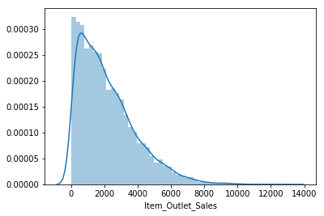

```python
# Plot the Item Outlet Sales
sns.distplot(sales["Item_Outlet_Sales"])
```

```python
#sales.loc[:, ["Item_Outlet_Sales", "Item_MRP"]] # Row, Column
```

```python
# desc stats
sales.Item_Outlet_Sales.describe()
```

```
count     8523.000000
mean      2181.288914
std       1706.499616
min         33.290000
25%        834.247400
50%       1794.331000
75%       3101.296400
max      13086.964800
Name: Item_Outlet_Sales, dtype: float64
```

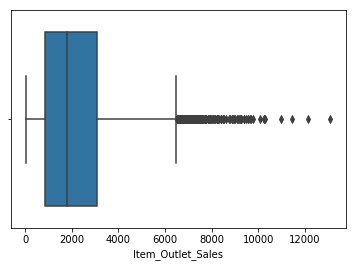

```python
# Boxplot
sns.boxplot(sales.Item_Outlet_Sales)
```

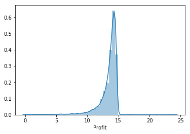

```python
sns.distplot(sales.Profit)
```

```python
sales.Profit.describe()
```

```
count    8523.000000
mean       13.414514
std         1.701840
min         0.100000
25%        13.150000
50%        13.900000
75%        14.300000
max        24.000000
Name: Profit, dtype: float64
```

```python
sales.Item_Outlet_Sales.skew()
```

```
1.1775306028542798
```

```python
sales.Profit.skew()
```

```
-3.3798077736299312
```

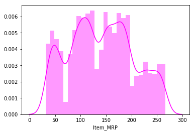

```python
sns.distplot(sales.Item_MRP, color = "magenta")
```

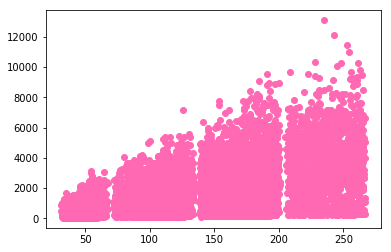

```python
plt.scatter(sales.Item_MRP, sales.Item_Outlet_Sales,
            color = "hotpink")
```

#### Boxplot

- Boxplot is a numerical summary of the data that consists of Min, Max, 25th Percentile, Median (50th) and 75th Percentile data
- We can identify the Outliers basis the Boxplot
- We calculate the Inter Quartile Range (IQR) => 75-25
- Lower Limit = Q1-1.5*IQR
- Upper Limit = Q3+1.5*IQR

**Note - Any value which is less than Lower Limit or Greater than Upper Limit is considered to be an Outlier**

```python
# Find the Q1, Q3 of Item Outlet Sales

print("Q1:", np.quantile(sales.Item_Outlet_Sales, 0.25))
print("Q2:", np.quantile(sales.Item_Outlet_Sales, 0.50))
print("Q3:", np.quantile(sales.Item_Outlet_Sales, 0.75))
print("Max:", np.quantile(sales.Item_Outlet_Sales, 1))
```

```
Q1: 834.2474
Q2: 1794.3310000000001
Q3: 3101.2964
Max: 13086.9648
```

```python
sales.Item_Outlet_Sales.quantile(0.45)
```

```
1593.9252
```

```python
# Quantile of whole data -0.25
sales.quantile(0.25)
```

```
Item_Weight                     7.720000
Item_Visibility                 0.026989
Item_MRP                       93.800000
Outlet_Establishment_Year    1987.000000
Item_Outlet_Sales             834.247400
Profit                         13.150000
Name: 0.25, dtype: float64
```

```python
# Basic Functions - mean, median, mode, variance, standard deviation
sales.mean()
```

```
Item_Weight                    11.676740
Item_Visibility                 0.066132
Item_MRP                      140.998838
Outlet_Establishment_Year    1997.831867
Item_Outlet_Sales            2181.288914
Profit                         13.414514
dtype: float64
```

```python
sales.median()
```

```
Item_Weight                    11.800000
Item_Visibility                 0.053931
Item_MRP                      142.700000
Outlet_Establishment_Year    1999.000000
Item_Outlet_Sales            1794.331000
Profit                         13.900000
dtype: float64
```

```python
sales.mode()
```

|  | Item_Identifier | Item_Weight | Item_Fat_Content | Item_Visibility | Item_Type | Item_MRP | Outlet_Identifier | Outlet_Establishment_Year | Outlet_Size | Outlet_Location_Type | Outlet_Type | Item_Outlet_Sales | Profit |
| --- | --- | --- | --- | --- | --- | --- | --- | --- | --- | --- | --- | --- | --- |
| 0 | FDG33 | 0.0 | Low Fat | 0.0 | Fruits and Vegetables | 139.6 | OUT027 | 1985.0 | Medium | Tier 2 | Supermarket Type1 | 958.752 | 14.3 |
| 1 | FDW13 | NaN | NaN | NaN | NaN | NaN | NaN | NaN | NaN | NaN | NaN | NaN | NaN |

```python
sales.var()
```

```
Item_Weight                  3.337201e+01
Item_Visibility              2.662335e-03
Item_MRP                     3.876071e+03
Outlet_Establishment_Year    7.008637e+01
Item_Outlet_Sales            2.912141e+06
Profit                       2.896258e+00
dtype: float64
```

```python
sales.std() # ddof = 1 is used if calculated for samples
```

```
Item_Weight                     5.776851
Item_Visibility                 0.051598
Item_MRP                       62.258099
Outlet_Establishment_Year       8.371760
Item_Outlet_Sales            1706.499616
Profit                          1.701840
dtype: float64
```

```python
# Covariance and Correlation
sales.loc[:, ["Item_Visibility", "Item_Outlet_Sales"]].corr()
```

|  | Item_Visibility | Item_Outlet_Sales |
| --- | --- | --- |
| Item_Visibility | 1.000000 | -0.128625 |
| Item_Outlet_Sales | -0.128625 | 1.000000 |

```python
# Covariance
np.cov(sales.Item_MRP, sales.Item_Outlet_Sales)
```

```
array([[   3876.07088459,   60299.00607842],
       [  60299.00607842, 2912140.93849972]])
```

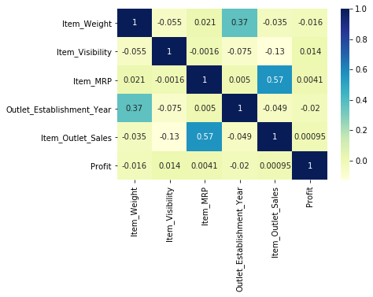

```python
sns.heatmap(sales.corr(), annot =  True,
            cmap = "YlGnBu")
```

```python
# Cat Variable
sales.head(2)
```

|  | Item_Identifier | Item_Weight | Item_Fat_Content | Item_Visibility | Item_Type | Item_MRP | Outlet_Identifier | Outlet_Establishment_Year | Outlet_Size | Outlet_Location_Type | Outlet_Type | Item_Outlet_Sales | Profit |
| --- | --- | --- | --- | --- | --- | --- | --- | --- | --- | --- | --- | --- | --- |
| 0 | FDA15 | 9.30 | Low Fat | 0.016047 | Dairy | 249.8 | OUT049 | 1999 | Medium | Tier 2 | Supermarket Type1 | 3735.1380 | 11.5 |
| 1 | DRC01 | 5.92 | Regular | 0.019278 | Soft Drinks | 48.3 | OUT018 | 2009 | Medium | Tier 2 | Supermarket Type2 | 443.4228 | 14.3 |

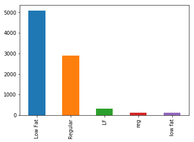

```python
sales.Item_Fat_Content.value_counts().plot(kind = "bar")
```

```python
# Replacing the values

sales.Item_Fat_Content.replace(to_replace=["LF", "low fat"],
                              value = ["Low Fat", "Low Fat"],
                              inplace = True)
```

```python
sales.Item_Fat_Content.replace(to_replace=["reg"], value = ["Regular"],
                              inplace = True)
```

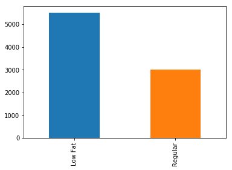

```python
sales.Item_Fat_Content.value_counts().plot(kind = "bar")
```

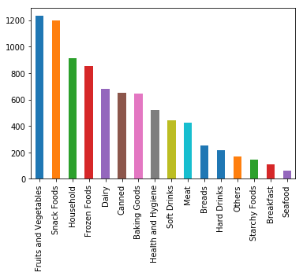

```python
# Item Type

sales.Item_Type.value_counts().plot(kind = "bar")
```

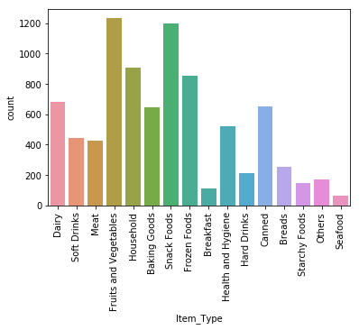

```python
# sales.Item_Type.value_counts().plot(kind = "bar")
sns.countplot(sales.Item_Type)
plt.xticks(rotation = 90)
plt.show()
```

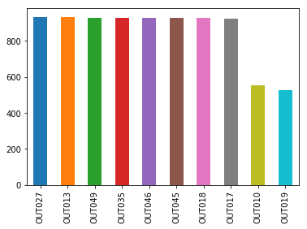

```python
# Plot Outlet ID
sales.Outlet_Identifier.value_counts().plot(kind = "bar")
```

```python
sales.Outlet_Location_Type.value_counts()
```

```
Tier 2    2793
Tier1     2388
Tier 3     932
?          120
  --       109
  -         67
na          48
NAN         16
Name: Outlet_Location_Type, dtype: int64
```

```python
sales.Outlet_Type.value_counts()
```

```
Supermarket Type1    5577
Grocery Store        1083
Supermarket Type3     935
Supermarket Type2     928
Name: Outlet_Type, dtype: int64
```